# Most successful method of winning in UFC

Author

Brandon Ansbergs

# Introduction

Mixed martial arts, particularly the Ultimate Fighting Championship (UFC), provides an intriguing arena for analyzing fighter performance metrics. This study aims to investigate the relationship between different methods of winning in UFC fights and the success of fighters. By examining factors such as knockouts, submissions, and decision victories, we seek to identify patterns and preferences among fighters and assess the effectiveness of various winning strategies.

# Design the Study

The population of interest encompasses all UFC fighters, and the research question focuses on uncovering the nature of the relationship between winning methods and fighter success. This analysis will utilize both quantitative and categorical data, including match outcomes and specific winning techniques. The chosen statistical tool for analysis is the chi-squared test for independence, enabling us to explore the associations between winning methods and fighter success rates, and specifically which corner they win in (Red or Blue).

# Collect the Data

The dataset for this study was obtained from Kaggle, providing comprehensive records of UFC fights, including details on winning methods and fighter performance metrics.This data set contains data from when the UFC started (1993) to a recent UFC card of 2023.

# Describe/Summarize the Data

```r
library(tidyverse)
library(mosaic)
library(rio)
library(ggplot2)
library(ggrepel)
library(pander)

# Read the data
temp<- import("C:\\Users\\bansb\\OneDrive\\Desktop\\MATH 221D\\UFC_ most strikes landed by fighters worldwide 2022 _ Statista_files\\UFC_data.csv")
temp <- temp %>% filter(win_by != "Other")

# Summarize the data
head(temp)
```

```
          R_fighter      B_fighter R_KD B_KD R_SIG_STR. B_SIG_STR.
1 Aljamain Sterling  Sean O'Malley    0    1   17 of 35   25 of 35
2     Chris Weidman   Brad Tavares    0    0   37 of 92  70 of 115
3        Neil Magny      Ian Garry    0    0   27 of 66  91 of 150
4       Marlon Vera   Pedro Munhoz    0    0 141 of 251 113 of 246
5       Zhang Weili   Amanda Lemos    1    0 163 of 217   24 of 63
6 Da'Mon Blackshear Mario Bautista    0    0  90 of 174  79 of 137
  R_SIG_STR_pct B_SIG_STR_pct R_TOTAL_STR. B_TOTAL_STR.   R_TD    B_TD R_TD_pct
1           48%           71%     24 of 46     26 of 36 0 of 2  0 of 0       0%
2           40%           60%     39 of 94    71 of 116 0 of 8  0 of 0       0%
3           40%           60%     51 of 93   111 of 171 0 of 2  2 of 2       0%
4           56%           45%   141 of 251   113 of 246 0 of 1  0 of 1       0%
5           75%           38%   296 of 358     29 of 68 6 of 7  0 of 0      85%
6           51%           57%   108 of 192   102 of 161 4 of 7 2 of 10      57%
  B_TD_pct R_SUB_ATT B_SUB_ATT R_REV B_REV R_CTRL B_CTRL     R_HEAD    B_HEAD
```

[output cut: 34 more lines]

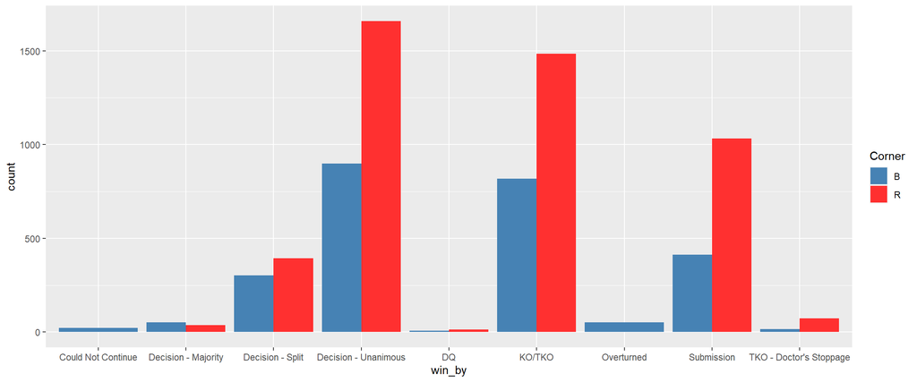

```r
# Visualize the distribution of wins by method
ggplot(temp)+
  geom_bar(aes(x = win_by, fill = Corner), position = position_dodge()) +
  scale_fill_manual(values=c("steelblue", "firebrick1"))
```

# Make Inference

```r
# Perform chi-squared test for independence
table <- table(temp$win_by, temp$Corner)
ufc_chi <- chisq.test(table)
pander(ufc_chi$observed)
```

|  | B | R |
| --- | --- | --- |
| **Could Not Continue** | 23 | 0 |
| **Decision - Majority** | 52 | 36 |
| **Decision - Split** | 303 | 394 |
| **Decision - Unanimous** | 898 | 1658 |
| **DQ** | 7 | 13 |
| **KO/TKO** | 818 | 1484 |
| **Overturned** | 51 | 0 |
| **Submission** | 412 | 1032 |
| **TKO - Doctor’s Stoppage** | 16 | 72 |

```r
ufc_chi
```

```
    Pearson's Chi-squared test

data:  table
X-squared = 217.5, df = 8, p-value < 2.2e-16
```

```r
pander(ufc_chi$expected)
```

|  | B | R |
| --- | --- | --- |
| **Could Not Continue** | 8.163 | 14.84 |
| **Decision - Majority** | 31.23 | 56.77 |
| **Decision - Split** | 247.4 | 449.6 |
| **Decision - Unanimous** | 907.2 | 1649 |
| **DQ** | 7.099 | 12.9 |
| **KO/TKO** | 817.1 | 1485 |
| **Overturned** | 18.1 | 32.9 |
| **Submission** | 512.5 | 931.5 |
| **TKO - Doctor’s Stoppage** | 31.23 | 56.77 |

The chi-squared test results reveal a statistically significant association between winning method and fighter success in UFC matches (χ² = 217.5, df = 8, p < 2.2e-16), indicating that the method by which a fighter achieves victory is not independent of their overall success in UFC bouts.

# Conclusion

The chi-squared test results suggest a significant association between winning method and fighter success in UFC matches. However, further examination reveals intriguing insights that warrant consideration.

Upon analyzing the contingency table, it becomes evident that certain winning methods are disproportionately favored by fighters assigned to the blue corner. This disparity raises questions about the independence of winning method and corner assignment. Traditionally, the blue corner is assigned to fighters perceived as underdogs or less experienced, while the red corner is reserved for favorites or higher-ranked competitors. This inherent bias in corner assignment could influence the observed relationships and skew the results of the chi-squared test.

Moreover, the presence of categories containing only blue suggests potential confounding factors or incomplete data, further complicating the interpretation of results. It is imperative to acknowledge these nuances and exercise caution when drawing conclusions from the analysis.

In conclusion, while the chi-squared test highlights statistically significant associations between winning methods and fighter success in UFC matches, the presence of confounding variables and biases inherent in corner assignments underscore the need for more comprehensive analyses and considerations of contextual factors. Future research should explore these intricacies to provide a deeper understanding of the dynamics influencing fighter performance and success in mixed martial arts competitions.